# Us County Map and Eastern Orthodox Parishes

The religious census from www.thearda.com provides a detailed view by us counties of the number of congregations and people belonging to varis types of worship. As an Orthodox priest, I find this most interesting to see how few Eastern Orthodox parishes there are in the US and when there is a collection of parishes it tends to be centered in urban area with large foriegn populations. In other words, parishes tend to be renewed by multiple waves of immigration from Europe.

The below script will create a choropleth map of US counties with a scaled count of parishes. The black counties mean that there is no Eastern Orthodox parish in that county as of the 2010 relgious census.

```r
# script for querying the religious census and creating a map
library(foreign)
library(devtools) # load the latest version of Ari's package
install_github("choroplethr", "trulia")
```

[output not shown]

```r
library(choroplethr)
library(ggplot2) # this seems to help choroplethr run better
library(dplyr) # this is becoming my goto data processing tool though I miss proc sql;
#http://www.thearda.com/download/download.aspx?file=U.S.%20Religion%20Cens
url = "http://www.thearda.com/download/download.aspx?file=U.S.%20Religion%20Census%20Religious%20Congregations%20and%20Membership%20Study,%202010%20(County%20File).DTA"
relig <- read.dta(url)
```

This vector contains the numeric value of the columns for needed values. I am trimming the original data as it comes with 568 variables and is not practical for working with. If you want to create a different map you will need to do a subset of the columnes for say Nazarine or Methododist.

[output not shown]

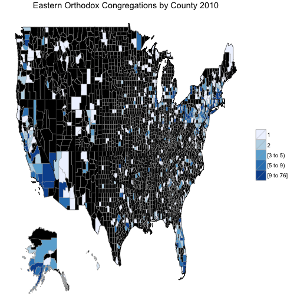

```r
# this data grabs the total count for orthodox churchs definitions found in religion.TXT
orthodox <- c(16, 17, 18, 562, 563, 564, 565, 566, 567, 568)

# this trims the dataset, removes the na, orders by most population counties and changes the names for choroplethr mapping
reli <- select(relig, orthodox) %.%
       # filter(!( stabbr %in% c("AK", "HI"))) %.% # newer version has AK & HI inset nice
        filter(complete.cases(orthcng)) %.%
        arrange(-POP2010) %.%
        mutate(region = fips, value = orthcng )

# map using choroplethr
 choroplethr(reli, "county", num_buckets=8, title="Eastern Orthodox Congregations by County 2010")
```